# Challenge 4

Author

Scott Brydon

#### Loading California and Avocado Data

- The data, which represents “Median sales price of existing single family homes in California in March 2021 and March 2022, by county” was pulled from https://www.statista.com/statistics/1268547/sales-price-of-existing-single-family-homes-in-california/.

```r
library(tidyverse)
library(here)
library(readxl)
avocados <- read_csv(here("data", "avocado.csv"))
cali_housing <- read_xlsx(here("data", "California Housing Prices.xlsx"),
                          sheet = "Data",
                          skip = 4) |>
  rename("region" = "...1",
         "March2021" = "Mar '21",
         "March2022" = "Mar '22")

#California regions
california_regions <- tibble(CaliforniaRegions = c("San Francisco", "San Diego", "Los Angeles",
                             "Sacramento"))

region_prices_cali <- cali_housing |>
  semi_join(california_regions, by = c("region" = "CaliforniaRegions"))

#Removing spaces to match Avocado dataset format
region_prices_cali$region[region_prices_cali$region == "San Francisco"] <- "SanFrancisco"
region_prices_cali$region[region_prices_cali$region == "San Diego"] <- "SanDiego"
region_prices_cali$region[region_prices_cali$region == "Los Angeles"] <- "LosAngeles"
```

```r
#Merging with Avocados
housing_avocados_cali <- avocados |>
  inner_join(region_prices_cali, by = "region") |>
  select(AveragePrice, `Total Volume`, region, March2022) |>
  mutate(March2022 = as.factor(March2022))
```

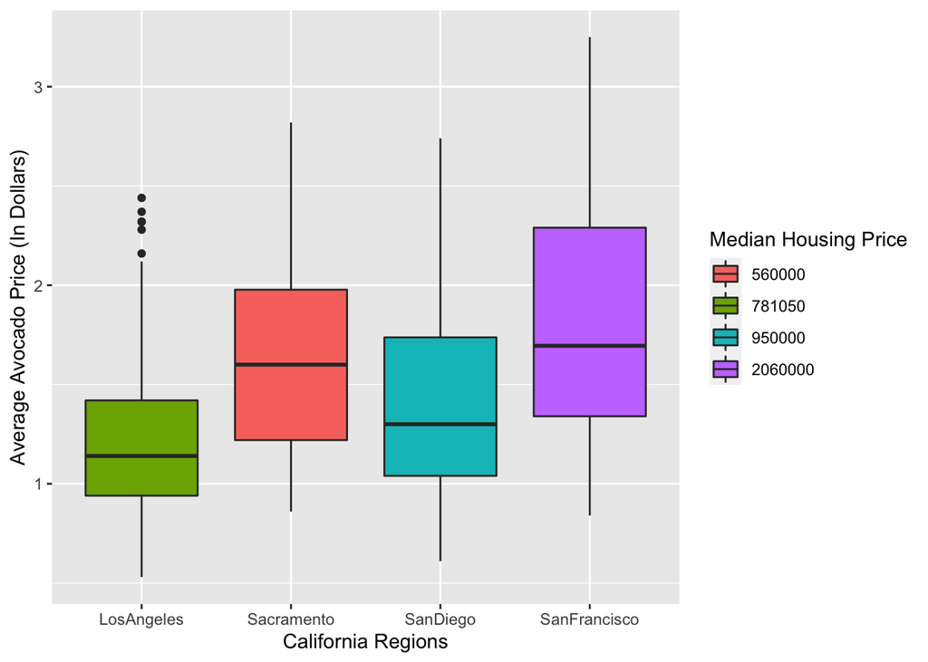

```r
options(scipen = 999)

#Finding Correlations
housing_avocados_cali |>
  group_by(region, March2022) |>
  ggplot(mapping = aes(x = region, y = AveragePrice, fill = March2022)) +
  geom_boxplot() +
  labs(x = "California Regions",
       y = "Average Avocado Price (In Dollars)",
       fill = "Median Housing Price")
```

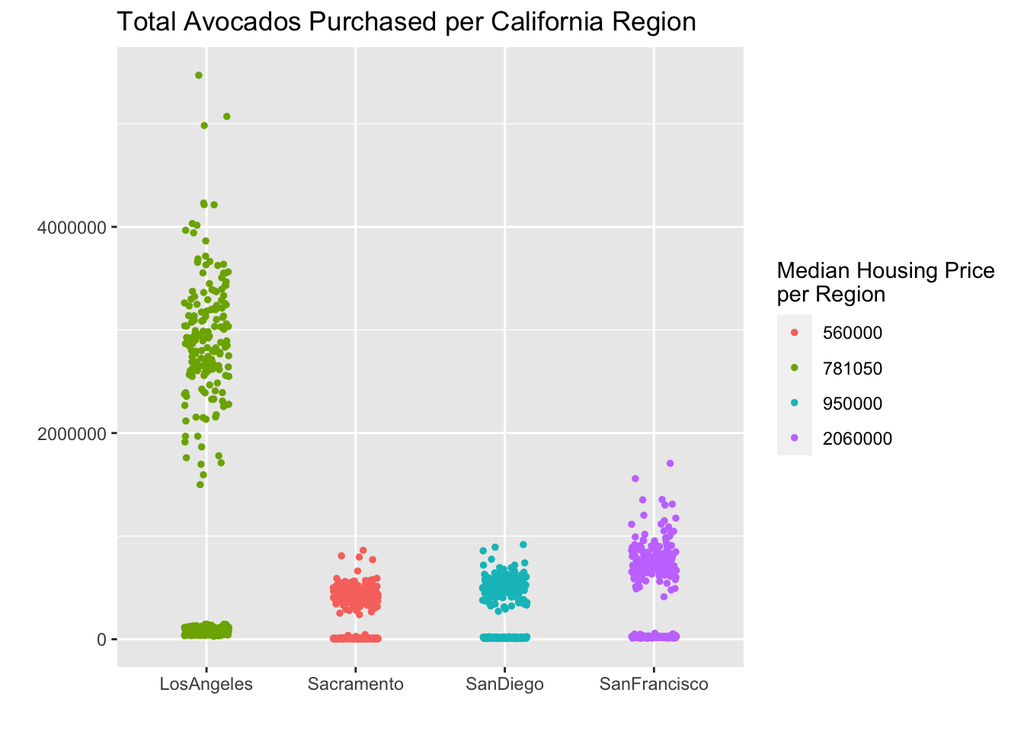

```r
housing_avocados_cali |>
  group_by(region, March2022) |>
  ggplot(mapping = aes(x = region, y = `Total Volume`, color = March2022)) +
  geom_jitter(width = 0.15, size = 1) +
  labs(x = "",
       y = "",
       title = "Total Avocados Purchased per California Region",
       color = "Median Housing Price \nper Region")
```

Using our first graph to address the claim “Millennials can’t afford houses, because they spend all their money buying avocado toast”, brings us to the conclusion that as Millennials move to more expensive areas, average avocado prices will likely be higher. Therefore, they should reduce avocado toast consumption to help save some extra cash to afford their more expensive home. But average avocado price doesn’t vary much relative to the drastic differences in median housing prices, so Millennials have much more to worry about when saving money than their obsession with avocado toast. In conclusion, Millennials aren’t able to afford homes due to avocado toast consumption, but rather the insanely high median housing prices in California.

#### Revision Notes:

When I first created this plot after organizing the data-set I had found online, I had been having trouble with the median housing prices acting like a categorical variable since they weren’t continuous. I had originally been hoping to have some type of geom_line or geom_point with housing price as the explanatory variable, but that obviously wasn’t possible. When I knew that wasn’t possible, I should have put the housing price as a fill or color since it was no longer a viable explanatory variable. The main focus here is where in California we are, so putting housing price as an annotation makes that clear.

When I used the bar-plot originally for median housing price and total avocados purchased, I had forgotten that the total avocados purchased data hadn’t been summarized into one number like median housing price had. If I remember correctly, I figured I would use a box-plot instead, but due to all the small total purchase values I thought it looked to similar to a bar-plot. Until I started doing this revision, I hadn’t realized how many data points I had been covering up until I used a geom_point, which when accompanied with a jitter gives a very good picture of the total purchases in those regions over the duration of the data. in all, I need to get better as accompanying data types with the appropriate plots.